# Multi-Omic Analysis

Author

Antoine Chaillon

Published

April 11, 2026

# 1. Multi-Omic Normalization of the HIV Signature

**Data Harmonization & Subsetting Logic**

To isolate the long-term impact of cannabis on the inflammatory “milieu,” transcriptomic analysis was restricted to **Vehicle-treated MDM samples** ($n=36$). This ensures that the observed signatures reflect the donor’s historical in vivo exposure rather than acute ex vivo stimulation. Proteomic data was derived from matching donor plasma ($n=26$).

For multi-omic validation, MDM transcripts were mapped to plasma proteins using a one-to-many Ensembl-to-Symbol relational map, with multiple transcripts for a single symbol collapsed to the mean:

$$\bar{x}_{\text{Symbol}} = \frac{1}{n} \sum_{i=1}^{n} \text{ENSEMBL}_{i}$$

## 1.1 Establishing the Basal HIV Signature

To understand how cannabis modulates the macrophage environment, we first established the “Basal HIV Signature.” This was defined by comparing HIV+ and HIV- donors who were both cannabis-naive, using only the Vehicle-treated samples ($n=10$).

**Note**

Here I am using the pathways identified in the latest R code from Claude AI you shared on APR-10.

## 1.2 Defined Pathways of Interest

| Pathway ID | Gene Count | Gene List | Pathway |
| --- | --- | --- | --- |
| Acute_Phase_Response | 23 | CRP, SAA1, SAA2, FGA, FGB, FGG, ORM1, ORM2, APCS, HP, HPR, LBP, ITIH1, ITIH2, ITIH3, ITIH4, PTX3, SERPINA1, SERPINA3, A2M, TTR, RBP4, CFH | Acute Phase Response |
| Macrophage_Activation | 21 | CD14, CD68, MRC1, MSR1, ITGAM, ITGAX, CD163, CD80, CD86, TNF, IL1B, IL6, IL8, CXCL10, CCL2, CCL5, HMOX1, MIF, SPP1, TREM2, CSF1R | Macrophage Activation |
| Neuroinflammation | 22 | GFAP, S100B, CXCL10, CCL2, TNF, IL1B, IL6, MMP9, TIMP1, VCAM1, ICAM1, VWF, VEGFA, NOS3, NGF, BDNF, CXCL12, CX3CL1, P2RX7, NLRP3, CASP1, IL18 | Neuroinflammation |
| NLRP3_Inflammasome | 10 | NLRP3, CASP1, IL1B, IL18, GSDMD, PYCARD, P2RX7, TXNIP, NEK7, HMGB1 | NLRP3 Inflammasome |
| TNF_Signaling | 16 | TNF, TNFRSF1A, TNFRSF1B, TRADD, RIPK1, FADD, CASP8, NFKB1, RELA, BIRC2, BIRC3, TRAF2, TRAF3, MAP3K7, IKBKB, IKBKG | TNF Signaling |
| IL6_JAK_STAT3 | 16 | IL6, IL6R, IL6ST, JAK1, JAK2, STAT3, SOCS1, SOCS3, CRP, FGA, FGB, FGG, HP, ORM1, SAA1, SAA2 | IL6 JAK STAT3 |
| IFN_alpha_beta | 20 | MX1, MX2, OAS1, OAS2, OAS3, OASL, IFIT1, IFIT2, IFIT3, IFITM1, IFITM3, ISG15, ISG20, RSAD2, HERC5, TRIM25, DDX58, IFIH1, CXCL10, IRF7 | IFN alpha beta |
| Complement | 22 | C1QA, C1QB, C1QC, C2, C3, C4A, C4B, C5, CFB, CFD, CFH, CFI, C1R, C1S, MBL2, MASP1, MASP2, CD55, CD59, SERPING1, VTN, CLU | Complement |
| Coagulation_Fibrinolysis | 22 | F2, F5, F7, F8, F9, F10, F13A1, F13B, FGA, FGB, FGG, VWF, PROS1, PROC, THBD, PLAT, PLAU, PLG, SERPINE1, SERPINC1, A2M, TFPI | Coagulation Fibrinolysis |
| Oxidative_Phosphorylation | 19 | ATP5PB, ATP5MC1, ATP5F1A, ATP5F1B, NDUFA1, NDUFA2, NDUFB10, NDUFS1, NDUFS2, UQCRC1, UQCRC2, COX4I1, COX5A, COX5B, SDHB, SDHC, SDHD, CYC1, CYCS | Oxidative Phosphorylation |

[output cut: 8 more lines]

## 1.2 The Transcriptomic “Sign-Flip”: Normalizing the HIV Environment

### Cannabis-Induced Normalization

| Pathway | NES_B_Raw | NES_M_Raw | NES_D_Raw | NES_A_Raw | Basal HIV (Naive) | Moderate vs Naive | Daily vs Naive | Any User vs Naive |
| --- | --- | --- | --- | --- | --- | --- | --- | --- |
| Acute_Phase_Response | -0.81 | -1.11 | -1.04 | -0.88 | -0.81 (0.72) | -1.11 (0.29) | -1.04 (0.41) | -0.88 (0.61) |
| Macrophage_Activation | 2.01 | -1.72 | -1.5 | -1.87 | 2.01 (&lt;0.001) | -1.72 (0.02) | -1.5 (0.05) | -1.87 (&lt;0.001) |
| Neuroinflammation | 1.73 | -2.11 | -1.85 | -2.1 | 1.73 (0.01) | -2.11 (&lt;0.001) | -1.85 (&lt;0.001) | -2.1 (&lt;0.001) |
| NLRP3_Inflammasome | 1.35 | -1.57 | -1.18 | -1.75 | 1.35 (0.13) | -1.57 (0.05) | -1.18 (0.26) | -1.75 (0.01) |
| TNF_Signaling | 0.8 | 0.57 | -1.21 | -1.12 | 0.8 (0.75) | 0.57 (0.96) | -1.21 (0.22) | -1.12 (0.31) |
| IL6_JAK_STAT3 | 0.99 | -1.12 | -1.67 | -1.2 | 0.99 (0.46) | -1.12 (0.29) | -1.67 (0.02) | -1.2 (0.24) |
| IFN_alpha_beta | 1.82 | 0.59 | -0.95 | -0.91 | 1.82 (&lt;0.001) | 0.59 (0.95) | -0.95 (0.53) | -0.91 (0.59) |
| Complement | 1.59 | -0.82 | -2.03 | -1.52 | 1.59 (0.03) | -0.82 (0.74) | -2.03 (&lt;0.001) | -1.52 (0.04) |
| Coagulation_Fibrinolysis | 1.2 | -0.66 | -1.16 | -1.36 | 1.2 (0.24) | -0.66 (0.92) | -1.16 (0.27) | -1.36 (0.12) |
| Oxidative_Phosphorylation | 1.04 | -1.96 | -1.37 | -1.8 | 1.04 (0.40) | -1.96 (&lt;0.001) | -1.37 (0.10) | -1.8 (&lt;0.001) |

[output cut: 8 more lines]

This table highlights the primary pathways upregulated in the HIV+ basal state (Blue columns) alongside their corresponding enrichment in cannabis users (Red columns). Data represents Normalized Enrichment Scores (NES) with associated p-values. A negative NES in the cannabis column represents a shift toward the transcriptional profile of an HIV-negative donor.

### Global Transcriptomic Normalization Map

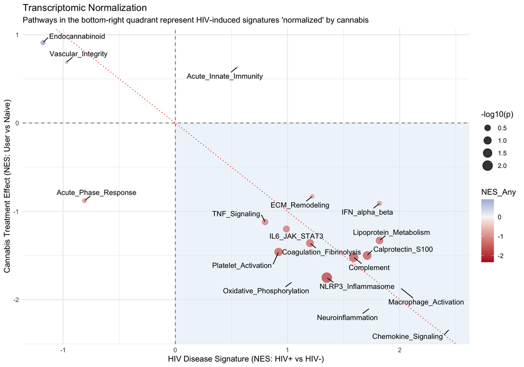

Figure 1: The Transcriptomic ‘Sign-Flip’. Comparison of HIV-induced pathway enrichment (x-axis) versus Cannabis-induced suppression (y-axis).

A comparison of the HIV Disease Signature (x-axis; HIV+ Naive vs HIV- Naive) against the Cannabis Treatment Effect (y-axis; HIV+ User vs HIV+ Naive). Pathways situated in the bottom-right quadrant represent biological processes induced by HIV infection that are subsequently suppressed by cannabis exposure. The dotted red line ($y = -x$) represents an ideal “perfect reversal.” The size of each point corresponds to the statistical significance of the cannabis-mediated suppression ($-log10(p)$).

## 1.3 Multi-Omic Validation: From Source to System

To verify that the transcriptomic suppression observed in our ex vivo MDM model reflects the systemic inflammatory state of the patients, we correlated the MDM RNA expression with the donors’ circulating plasma protein levels.

### Statistical Approach

The “Source-to-System” concordance was calculated using Pearson’s correlation coefficient ($r$) for lead-edge genes identified in the GSEA. For genes with multiple transcripts, we utilized the mean expression value (see equation above).

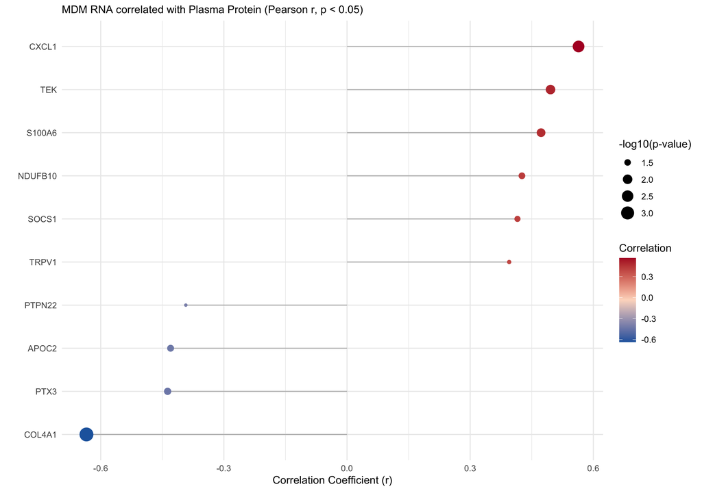

Figure 2: Validated Source-to-System Markers. Points represent genes where MDM RNA significantly correlates (p < 0.05) with systemic plasma protein levels.

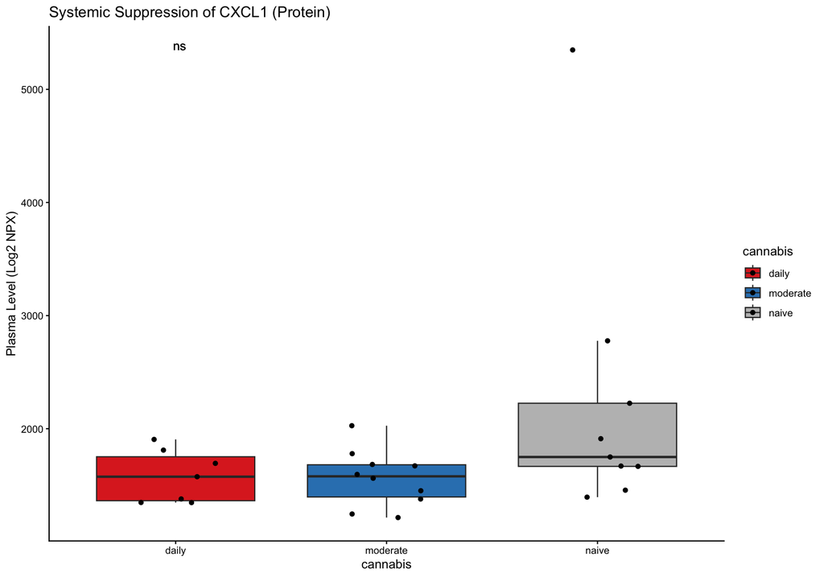

## 1.5 Summary of Multi-Omic Concordance

The following table summarizes the markers that successfully bridge the cellular and systemic datasets.

| Pathway | Validated Marker | Correlation (r) | p-value (Omic) | Cannabis Reversal (NES) |
| --- | --- | --- | --- | --- |
| Acute_Phase_Response | PTX3 | -0.4370269050076399 | 0.02558643546986832 | -0.8826228506458071 |
| Calprotectin_S100 | S100A6 | 0.4726562489686352 | 0.01475387941815701 | -1.495935166367578 |
| Chemokine_Signaling | CXCL1 | 0.5639797685600911 | 0.002692866581074779 | -2.337103200692241 |
| ECM_Remodeling | COL4A1 | -0.6347579024295202 | 0.0004954460097096182 | -0.8306629150579027 |
| Endocannabinoid | TRPV1 | 0.3949932348816929 | 0.04581696394789195 | 0.9067758017866032 |
| Endocannabinoid | PTPN22 | -0.3927124201680086 | 0.04719850784195508 | 0.9067758017866032 |
| IL6_JAK_STAT3 | SOCS1 | 0.4151411474969439 | 0.03494937085754637 | -1.203749212945238 |
| Lipoprotein_Metabolism | APOC2 | -0.4298040101982629 | 0.02841999245471837 | -1.325523651979545 |
| Oxidative_Phosphorylation | NDUFB10 | 0.4260109452612201 | 0.03000622740965498 | -1.799026482396389 |
| Vascular_Integrity | TEK | 0.4956845838812449 | 0.01002142580945592 | 0.68911936960018 |

# 2. Altered Cellular Responsiveness

The goal here is to determine if a macrophage from a cannabis user is “primed” differently, making it more or less responsive to inflammatory stimuli (IL1B) or cannabinoids (THC/CBD) added in the lab.

## 2.1 Conserved Transcriptional Program Following Acute IL-1β Challenge

To determine if chronic cannabis exposure results in “myeloid exhaustion” or altered sensitivity, we analyzed the acute response to inflammatory (IL-1β) and cannabinoid (THC, CBD) stimuli using a Likelihood Ratio Test (LRT).

We first analyzed the “Activation Potential” of MDMs by stimulating them with IL-1β. We modeled the response within each donor group to see if the magnitude of inflammatory induction differs.The response is defined by the log2 fold change ($\text{LFC}$) of gene expression ($G$) under stimulation ($\text{stim}$) compared to the vehicle ($\text{veh}$):

$$\text{LFC}\_{\text{IL1B}} = \log_2(G\_{\text{stim}}) - \log_2(G\_{\text{veh}})$$

The absence of genes reaching global significance ($FDR < 0.05$) indicates that the “Transcriptomic Normalization” associated with cannabis use does not result in myeloid exhaustion or a blunted capacity to respond to acute stimuli.

## 2.2 Divergence in Regulatory and Adhesion Markers

While the core inflammatory program remained stable, a subset of genes showed nominal evidence of differential responsiveness ($p < 0.01$). Notably, ITGA1 (Integrin Alpha-1) and LILRB1 (Leukocyte Immunoglobulin Like Receptor B1) exhibited blunted induction in cannabis users.

Table 1: Table 3. Nominally Significant Interaction Markers (IL-1β Response).

| SYMBOL | Interaction LFC | p-value | Base Expression |
| --- | --- | --- | --- |
| ITGA1 | -4.732576391251477 | 0.003398607172730757 | 52.88685301734397 |
| LILRB1 | -7.366050496574987 | 0.003800241711789464 | 33.01501120629396 |
| EBI3 | 0.1305546543716447 | 0.006066784806743102 | 461.6751254246932 |
| ZNF43 | 0.07341886762565862 | 0.00787377639881708 | 6.35758882309237 |

The $log_2$ Fold Change represents the “Interaction Effect.” A negative value (e.g., ITGA1: $-4.73$) indicates that the gene’s response to IL-1β was significantly attenuated in cannabis users compared to naive donors.

## 2.3 Visualizing Global Response Conservation

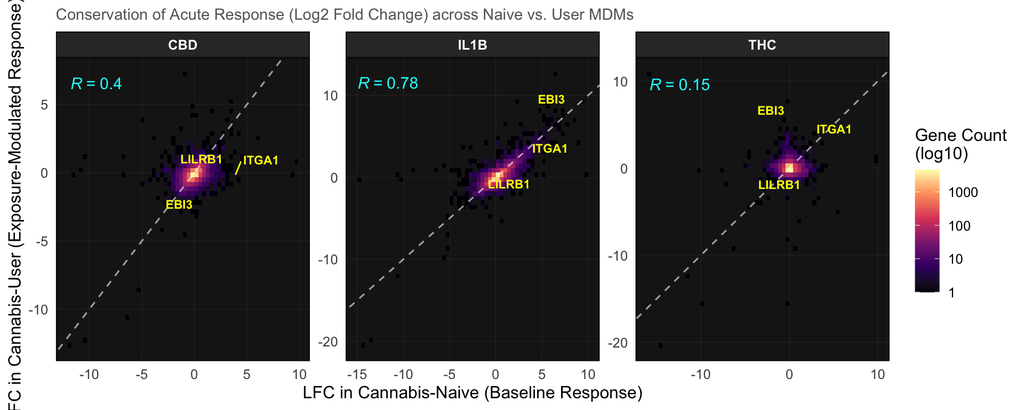

## 2.4 Acute Sensitivity to Cannabinoids (THC & CBD)

Now, we apply the same logic to THC and CBD. We want to know: Do the macrophages of daily users “care” less when you give them THC in the dish?

*The “Tolerance” Hypothesis*: If chronic users are desensitized, we expect to see a “blunted” diagonal in the concordance plot (a slope $< 1$) or a large cluster of genes with significant interaction terms.

| Acute Stimulation | Interaction Hits (p < 0.01) | Biological Interpretation |
| --- | --- | --- |
| IL-1β | 4 | Conserved Inflammatory Competence |
| THC | 4 | Minimal Receptor Desensitization |
| CBD | 4 | Consistent Anti-inflammatory Signaling |

The “Nominal Hits” represent genes where the transcriptional response to acute challenge differed between cannabis users and naive donors at a non-adjusted threshold of $p < 0.01$. The extremely low frequency of such events (4 genes out of ~15,000 tested) indicates that chronic cannabis exposure does not induce significant cellular tolerance or functional exhaustion in macrophages.

# Temptative discussion (AI)

In summary, these data define cannabis as a selective homeostatic modulator in the context of HIV: it successfully ‘reverses’ the chronic disease-associated transcriptome (Section 1) without compromising the innate immune system’s capacity to mount an acute response to secondary inflammatory or pharmacological stimuli (Section 2)